# T4: Exercise: Analysis of rare variants in families

Diana Barrientos González

31-05-2026

We take a look at the given Pedigree.

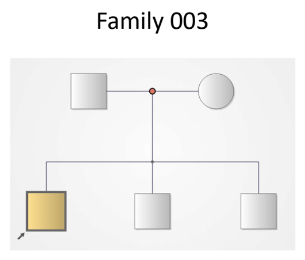

The patient has the following phenotype:

- Gross motor delay
- Global central hypotonia
- Mild dysmorphic facies
- Congenital transient torticollis

The phenotype has the typical characteristics of an autosomal recessive disorder.Therefore, we expect our individual to be homozygous, nevertheless we have to make other assumptions just in case we don’t overlook something.

Since we already have the annotation of the variants specific to our patient, we need to filter the variants.

**Note:**

Genome annotations used GRCh37 (Genome Reference Consortium Human Build 37), also known as hg19. This means that genome locations are not precisely as the ones on GRCh38 also known as hg38

## DATA IMPORT

```r
library(readxl)
FAM3 <- read_excel("~/Desktop/genomica/genomica_humana/FAM3.xlsx")
nrow(FAM3)
```

```
[1] 22548
```

**Total number of variants: 22548**

## VARIANT FILTERING BY ANNOTATIONS

- Remove synonymous variants

```r
FAM3 <- as.data.frame(FAM3)
# quitamos las variantes sinónimas como primer filtrado
filtro1 <-FAM3[FAM3[,18] != "synonymous SNV", ]
cat("El número de variantes restantes después de quitar las variantes sinónimas son:\n")
```

```
El número de variantes restantes después de quitar las variantes sinónimas son:
```

```r
nrow(filtro1)
```

```
[1] 11586
```

```r
cat("Froma de verificar que nuestro filtrado fue bueno:\n")
```

```
Froma de verificar que nuestro filtrado fue bueno:
```

```r
table(filtro1[,18])
```

```
        exonic;splicing     frameshift deletion    frameshift insertion
                     27                     106                      83
         ncRNA_splicing  nonframeshift deletion nonframeshift insertion
                      9                     163                     116
      nonsynonymous SNV                splicing            stopgain SNV
                   9944                    1038                      90
           stoploss SNV
                     10
```

## VARIANT FILTERING BY QUALITY

The filters to consider are:

- Genotype Quality >= 30

```r
FAM3[,8] <- as.numeric(FAM3[,8])
FAM3[,12] <- as.numeric(FAM3[,12])
FAM3[,46] <- as.numeric(FAM3[,46])

filtro2 <-FAM3[FAM3[,18] != "synonymous SNV" & FAM3[,13] >= 30,]
cat("The number of variants after the Q>=30 filter is:\n")
```

```
The number of variants after the Q>=30 filter is:
```

```r
nrow(filtro2)
```

```
[1] 11200
```

- Total Read Depth >= 10

In our dataset TR is Total Read depth

```r
filtro3 <-FAM3[FAM3[,18] != "synonymous SNV" & FAM3[,13] >= 30 & FAM3[,11] >= 10,]
cat("The number of variants with a total read depth >=10 es:\n")
```

```
The number of variants with a total read depth >=10 es:
```

```r
nrow(filtro3)
```

```
[1] 11056
```

- The total number of TRs for the variant must match the sum of the REF and ALT alleles

```r
filtro4 <- filtro3[which((filtro3[,9] + filtro3[,10]) == filtro3[,11]), ]
cat("The number of variants where RR + VR == TR es:\n")
```

```
The number of variants where RR + VR == TR es:
```

```r
nrow(filtro4)
```

```
[1] 10878
```

- Allele Balance > 20% ||.2 of the reads mark the ALT allele

```r
filtro5 <-filtro4[filtro4[,12] >= .2,]
cat("The number of variants with ratio/Allele Balance >= 20%  es:\n")
```

```
The number of variants with ratio/Allele Balance >= 20%  es:
```

```r
nrow(filtro5)
```

```
[1] 10510
```

- < 1% MAF in population studies

```r
filtro6 <-filtro5[filtro5[,46] < 0.01,]
cat("The number of variants less than 1% of the MAF is:\n")
```

```
The number of variants less than 1% of the MAF is:
```

```r
nrow(filtro6)
```

```
[1] 594
```